# Navigating R Studio for programming

Author

Silvie Cinková

Published

July 18, 2025

## 1 The four panes of RStudio

[figure not shown]

`File`, `Console`, `Environment`, and `Files` tabs

By default, RStudio opens with four panes. All but the top left one even have several tabs with their own menu bars. In this tutorial, I will call the panes with the names of the tabs in focus.

## 2 Console

- Command line of the bare R
- Type a command (e.g. `1 + 1`) and hit Enter to execute it.
- Console displays the output.
- `>` at line start: R is ready to accept your next command
- Console does not save your scripts. Use files to save your work.
- Clear Console: hit the broom icon or `Ctrl + L`.

[figure not shown]

De-clutter the Console with the broom icon.

## 3 File formats for writing scripts

[figure not shown]

File formats for writing R scripts

Quarto, R Notebook, and R Markdown are markdown-based formats you have learned about. They are fantastic when you need to accompany your code with text and report the results in a single file. But not all scripts require fancy presentation. If you just want to do something quick (but still worth saving for later reuse), you may prefer the bare R Script file (`.R`). It comes as an empty plain text file with the `.R` suffix.

## 4 Run a script with comments

[figure not shown]

Comment your code correctly.

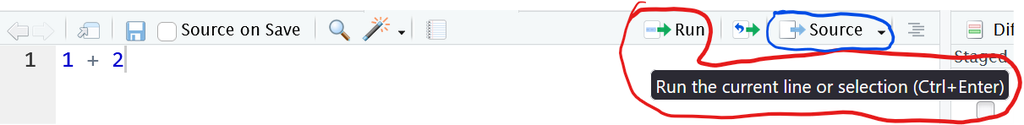

Highlight and *run* a line or several lines or *source* the whole file at once.

In this format, R reads each line as a command and will throw an error and stop at each line it cannot execute. When you want (you should) comment your code, you must put a fence `#` before the text to tell R to ignore it.

## 5 Environment pane

- lists objects currently loaded in R
  - variables
  - functions you have written
- Delete objects with the broom icon.
  - Toggle List and Grid view.
  - Grid view can mark individual objects for deletion.

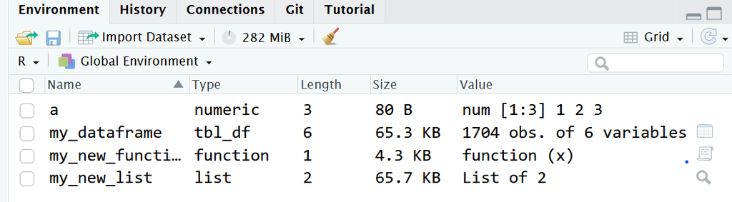

Environment with objects in Grid View

What you see is the so-called Global Environment. Each software library (aka software package) that you load (more later) will create its own environment. In this course, we will only consider the Global Environment.

## 6 Packages pane

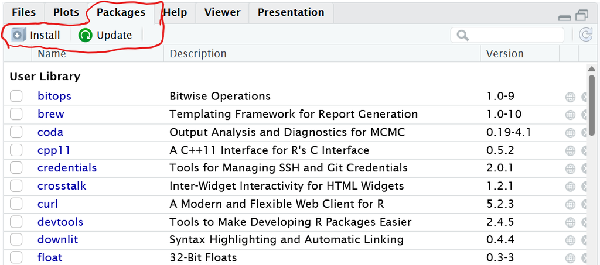

You typically install packages from https://cran.r-project.org/

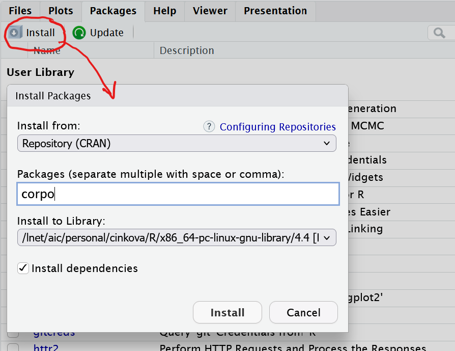

Install packages

A package sometimes has dependencies; i.e., requires other packages to work correctly. When you check `Install dependencies`, R will load all missing dependent packages automatically. CRAN is the official repository of R packages. But you can as well download a package from GitHub or elsewhere. You just adjust the source with `Configuring Repositories` in the `Install` menu.

## 7 Get Help

- Roll down menu top left pane
- Help tab in bottom right pane
- https://stackoverflow.com/questions
- MS Copilot, ChatGPT & Co. quite good.
- Wickham et al.: [*R for Data Science*](https://r4ds.hadley.nz/)
- Grolemund: [*Hands-On Programming with R*](https://rstudio-education.github.io/hopr/)
- https://www.tidyverse.org/

## 8 Plots pane

- plots output from Console/R file
- you can export them interactively

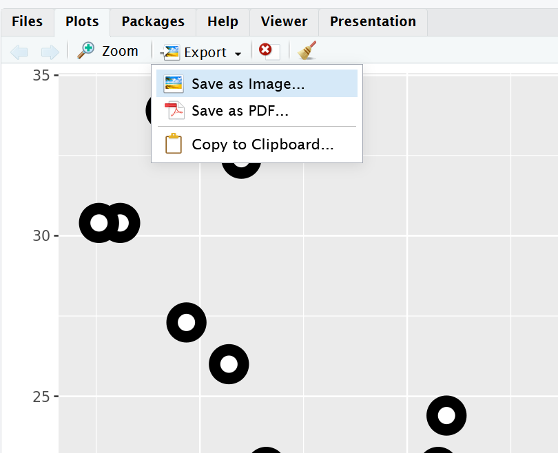

`Plots` pane